# Econometría Financiera: modelos econométricos del portafolio

Proyecto final · Portafolio en HowTheMarketWorks

**Alumno:** Carlos Salvide**Matrícula:** A01452194**Profesor:** Raymundo DiazEGADE Business School · Tecnológico de Monterrey**Fecha:** 08/11/2026

## Resumen ejecutivo

**Regresión lineal simple.** La beta diaria del portafolio es 0.70 (R² = 0.42). NVDA es la acción más sensible al mercado (β = 2.16) y KOF la más defensiva (β = 0.46). Con datos de minutos el R² cae (efecto Epps), y la beta móvil muestra un cambio de régimen: en los últimos seis meses COST tuvo beta -0.39 y el portafolio 0.00.

**Regresión lineal múltiple.** Agregar VIX, tasa a 10 años, USD/MXN y petróleo lleva el R² ajustado promedio de 0.372 a 0.376, sin multicolinealidad (VIF máximo 2.50): el mercado explica casi todo. En las horas seleccionadas, la volatilidad de la primera hora es 2.5 veces la del resto del día; el cierre no es significativamente distinto.

**Datos panel.** Con los reportes trimestrales, las pruebas de especificación favorecen el modelo de MCO agrupado (Hausman p = 0.646). La muestra es corta, por lo que la relación entre fundamentales y rendimiento es exploratoria.

**Series de tiempo (Box-Jenkins).** Los log-precios son I(1) y los rendimientos estacionarios. La ACF/PACF sugiere órdenes bajos; el mejor modelo por AIC es ARMA(2,2) (≡ ARIMA(2,1,2) en el log-valor) con residuos sin autocorrelación, aunque el BIC y auto.arima prefieren modelos más simples. El ARIMA supera al paseo aleatorio en 3 de 10 series; el pronóstico del portafolio a 10 días es $504,061.02 (IC 95%: $469,408.61 a $541,271.51).

**Intradía.** Por hora, el mejor modelo fuera de muestra fue SARIMA; la volatilidad tiene un ciclo dominante de una sesión (FFT ≈ 78 barras de 5 min).

**GARCH.** Persistencia α+β = 0.975; el mejor modelo de volatilidad es EGARCH(1,1). VaR 95% diario ≈ $7,724.87 sobre un valor de $501,129.99.

**Desempeño en HowTheMarketWorks.** La cuenta rinde 1.53% contra -4.90% del SPY (6.43 puntos porcentuales por encima del mercado).

**Estrategias.** Fuera de muestra, «Mínima varianza» tuvo la mejor razón de Sharpe (1.08 vs. 0.32 del portafolio actual). La alta concentración en COST es el principal riesgo del portafolio.

## 1. Datos

Fuente: Yahoo Finance, precios ajustados por dividendos y splits. Acciones del portafolio (9): COST, KOF, GOOG, NVDA, TGT, BAC, MSFT, AMZN, AAPL. Índice de mercado: S&P 500 (^GSPC) en datos diarios y el ETF SPY en datos intradía. Factores macro-financieros: VIX, rendimiento del bono del Tesoro a 10 años, tipo de cambio USD/MXN y petróleo WTI.

Tabla 1. Muestras por frecuencia

| Frecuencia | Observaciones | Desde | Hasta |
| --- | --- | --- | --- |
| Diaria | 1,255 | 2021-11-08 | 2026-11-06 |
| 60 minutos | 5,098 | 2023-12-11 09:30:00 | 2026-11-06 15:30:00 |
| 5 minutos | 4,680 | 2026-08-14 09:30:00 | 2026-11-06 15:55:00 |
| 1 minuto | 2,730 | 2026-10-29 09:30:00 | 2026-11-06 15:59:00 |

## 2. Portafolio en HowTheMarketWorks

Tabla 2. Composición del portafolio al 2026-11-06

| Ticker | Empresa | Acciones | Precio pagado | Último precio | Valor de mercado | Peso % | Ganancia/Pérdida | Rend. % |
| --- | --- | --- | --- | --- | --- | --- | --- | --- |
| COST | Costco | 300 | 988.12 | 1,053.56 | 316,068.02 | 63.07 | 19,632.02 | 6.62 |
| KOF | Coca-Cola FEMSA | 1,000 | 108.15 | 114.43 | 114,430.00 | 22.83 | 6,280.00 | 5.81 |
| GOOG | Alphabet | 100 | 340.32 | 283.93 | 28,393.00 | 5.67 | -5,639.00 | -16.57 |
| NVDA | NVIDIA | 100 | 241.74 | 186.64 | 18,664.00 | 3.72 | -5,510.00 | -22.79 |
| TGT | Target | 50 | 153.59 | 158.41 | 7,920.50 | 1.58 | 241.00 | 3.14 |
| BAC | Bank of America | 150 | 54.64 | 49.42 | 7,413.00 | 1.48 | -783.00 | -9.55 |
| MSFT | Microsoft | 10 | 531.86 | 530.61 | 5,306.10 | 1.06 | -12.50 | -0.24 |
| AMZN | Amazon | 10 | 251.55 | 259.30 | 2,593.00 | 0.52 | 77.50 | 3.08 |
| AAPL | Apple | 1 | 333.39 | 342.37 | 342.37 | 0.07 | 8.98 | 2.69 |
| TOTAL | Total |  |  |  | 501,129.99 | 100.00 | 14,295.00 | 2.94 |

El portafolio vale $501,129.99 y acumula una ganancia de $14,295.00 (2.94%) sobre un costo de $486,834.99. Está concentrado en COST (63.1%) y KOF (22.8%), lo que hace que su riesgo dependa principalmente de esas dos emisoras.

Tabla 3. Resumen de la cuenta en HowTheMarketWorks (Account Balances)

| Concepto | Valor |
| --- | --- |
| Efectivo inicial | 1,000,000.00 |
| Efectivo disponible | 514,127.84 |
| Valor de las posiciones | 519,601.22 |
| Valor total de la cuenta | 1,015,257.81 |
| Rendimiento de la cuenta % | 1.53 |
| Rendimiento del SPY en el mismo periodo % | -4.90 |
| Comisiones | 120.00 |
| Dividendos cobrados | 1,083.83 |
| Operaciones realizadas | 12.00 |

La cuenta del concurso rinde 1.53% frente a -4.90% del SPY en el mismo periodo: 6.43 puntos porcentuales por encima del mercado. El 50.6% de la cuenta permanece en efectivo, lo que reduce la exposición al riesgo de mercado y explica parte del mejor desempeño relativo en un periodo de baja.

Tabla 4. Estadística descriptiva de los rendimientos logarítmicos diarios

| Activo | Rend. anual % | Vol. anual % | Sharpe | Asimetría | Curtosis exceso | p Jarque-Bera |
| --- | --- | --- | --- | --- | --- | --- |
| COST | 15.902 | 23.129 | 0.515 | -0.785 | 8.266 | 0 |
| KOF | 18.691 | 24.647 | 0.596 | 0.044 | 0.965 | 0 |
| GOOG | 13.099 | 32.450 | 0.280 | -0.193 | 4.103 | 0 |
| NVDA | 36.291 | 51.465 | 0.627 | 0.231 | 3.720 | 0 |
| TGT | -6.305 | 37.097 | -0.278 | -2.106 | 30.234 | 0 |
| BAC | 3.324 | 26.685 | -0.025 | -0.210 | 3.842 | 0 |
| MSFT | 9.949 | 28.274 | 0.210 | 0.378 | 6.020 | 0 |
| AMZN | 7.965 | 36.618 | 0.108 | 0.132 | 5.136 | 0 |
| AAPL | 16.997 | 28.059 | 0.463 | 0.182 | 5.623 | 0 |
| PORTAFOLIO | 15.781 | 18.525 | 0.636 | -0.739 | 8.482 | 0 |
| S&P 500 | 9.052 | 17.122 | 0.295 | -0.012 | 6.293 | 0 |

Todos los p-valores de Jarque-Bera son prácticamente cero: los rendimientos no son normales, presentan colas pesadas (curtosis en exceso positiva). Por eso se usan errores estándar robustos en las regresiones y una distribución t-Student en los modelos GARCH.

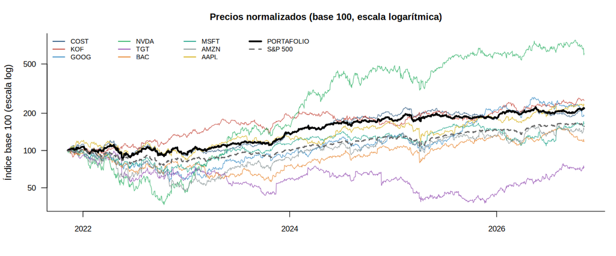

Figura 1. Desempeño histórico (base 100): acciones, portafolio y S&P 500

## 3. Regresión lineal simple: CAPM

Tabla 5. CAPM con rendimientos diarios (2021-2026)

| Activo | Alfa anual % | Beta | t Beta (HC1) | p Beta | R2 | Durbin-Watson | p Breusch-Pagan | p Jarque-Bera | N |
| --- | --- | --- | --- | --- | --- | --- | --- | --- | --- |
| COST | 9.867 | 0.667 | 13.328 | 0 | 0.244 | 1.919 | 0.000 | 0 | 1,254 |
| KOF | 14.483 | 0.465 | 10.839 | 0 | 0.104 | 2.082 | 0.354 | 0 | 1,254 |
| GOOG | 1.740 | 1.255 | 28.712 | 0 | 0.438 | 1.918 | 0.542 | 0 | 1,254 |
| NVDA | 16.761 | 2.158 | 33.975 | 0 | 0.515 | 2.090 | 0.891 | 0 | 1,254 |
| TGT | -14.685 | 0.926 | 9.965 | 0 | 0.183 | 1.997 | 0.000 | 0 | 1,254 |
| BAC | -5.396 | 0.963 | 20.347 | 0 | 0.382 | 1.862 | 0.202 | 0 | 1,254 |
| MSFT | -0.444 | 1.148 | 30.825 | 0 | 0.483 | 1.980 | 0.446 | 0 | 1,254 |
| AMZN | -5.715 | 1.511 | 25.606 | 0 | 0.499 | 1.950 | 0.715 | 0 | 1,254 |
| AAPL | 6.500 | 1.160 | 26.726 | 0 | 0.501 | 1.814 | 0.588 | 0 | 1,254 |
| PORTAFOLIO | 9.400 | 0.705 | 19.269 | 0 | 0.425 | 1.902 | 0.000 | 0 | 1,254 |

La beta del portafolio es 0.705 (R² = 0.425): por cada 1% que se mueve el S&P 500, el portafolio se mueve en promedio 0.70%. La acción más agresiva es NVDA (β = 2.16) y la más defensiva KOF (β = 0.46). Los p-valores de Breusch-Pagan bajos indican heteroscedasticidad, por lo que la inferencia se basa en errores robustos HC1; el estadístico Durbin-Watson cercano a 2 indica ausencia de autocorrelación de primer orden.

[figure not shown]

Figura 2. Línea característica del portafolio (rendimientos diarios)

Tabla 6. CAPM por frecuencia de muestreo: diaria, horas y minutos

| Acción | Beta Diaria | Beta 60 min | Beta 5 min | Beta 1 min | R2 Diaria | R2 60 min | R2 5 min | R2 1 min |
| --- | --- | --- | --- | --- | --- | --- | --- | --- |
| COST | 0.667 | 0.554 | -0.105 | -0.188 | 0.244 | 0.196 | 0.004 | 0.016 |
| KOF | 0.465 | 0.399 | 0.187 | 0.216 | 0.104 | 0.044 | 0.004 | 0.009 |
| GOOG | 1.255 | 1.065 | 1.260 | 1.199 | 0.438 | 0.375 | 0.273 | 0.338 |
| NVDA | 2.158 | 1.896 | 1.875 | 2.079 | 0.515 | 0.502 | 0.439 | 0.578 |
| TGT | 0.926 | 0.864 | 0.350 | 0.162 | 0.183 | 0.234 | 0.016 | 0.007 |
| BAC | 0.963 | 0.980 | 0.745 | 0.704 | 0.382 | 0.391 | 0.105 | 0.194 |
| MSFT | 1.148 | 0.944 | 1.100 | 1.130 | 0.483 | 0.449 | 0.217 | 0.261 |
| AMZN | 1.511 | 1.280 | 1.376 | 1.358 | 0.499 | 0.512 | 0.301 | 0.305 |
| AAPL | 1.160 | 1.030 | 0.778 | 0.793 | 0.501 | 0.400 | 0.121 | 0.193 |

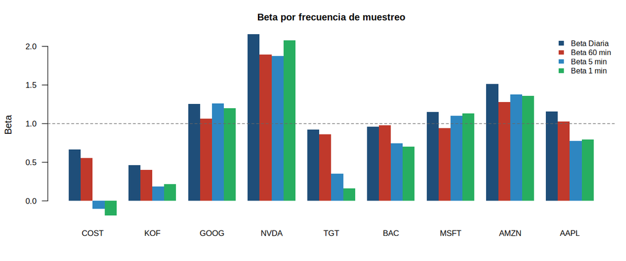

Figura 3. Betas estimadas con datos diarios, por hora y por minuto

En la mayoría de las acciones los R² con datos de 5 y 1 minuto son mucho menores que con datos diarios y varias betas disminuyen. Es el efecto Epps: a muy alta frecuencia la negociación no sincrónica y el ruido de microestructura atenúan la covarianza con el mercado; el ADR de KOF, menos líquido, es un ejemplo claro. Las acciones más líquidas (NVDA, MSFT, AMZN, GOOG) conservan betas similares en todas las frecuencias.

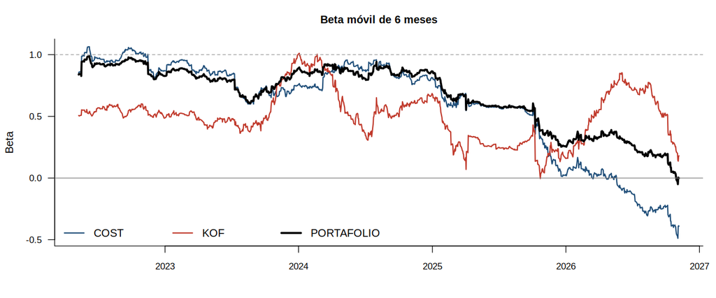

Figura 4. Beta móvil de 126 días (6 meses) frente al S&P 500

La beta no es constante en el tiempo. En los últimos seis meses la beta de COST es -0.39 (correlación con el S&P 500 de -0.25), frente a 0.67 en toda la muestra, y la del portafolio bajó a 0.00. Como los datos de 5 y 1 minuto cubren solo ese periodo reciente, las betas intradía negativas de COST reflejan este cambio de régimen (Costco se movió en sentido contrario al mercado) y no un error en los datos.

## 4. Regresión lineal múltiple

Tabla 7. Regresión múltiple con factores (diario; p-valores robustos HC1)

| Activo | β Mercado | p Mercado | β VIX | p VIX | β Tasa10Y | p Tasa10Y | β USDMXN | p USDMXN | β Petroleo | p Petroleo | R2 aj. | p F | DW | N |
| --- | --- | --- | --- | --- | --- | --- | --- | --- | --- | --- | --- | --- | --- | --- |
| COST | 0.826 | 0 | 0.029 | 0.001 | -0.007 | 0.261 | 0.032 | 0.534 | -0.001 | 0.970 | 0.252 | 0 | 1.935 | 1,254 |
| KOF | 0.405 | 0 | -0.009 | 0.321 | -0.026 | 0.000 | -0.076 | 0.216 | -0.004 | 0.841 | 0.114 | 0 | 2.115 | 1,254 |
| GOOG | 1.392 | 0 | 0.024 | 0.007 | 0.005 | 0.523 | -0.033 | 0.574 | -0.027 | 0.070 | 0.441 | 0 | 1.922 | 1,254 |
| NVDA | 2.233 | 0 | 0.012 | 0.400 | 0.026 | 0.029 | -0.008 | 0.934 | -0.001 | 0.960 | 0.516 | 0 | 2.095 | 1,254 |
| TGT | 1.009 | 0 | 0.017 | 0.173 | -0.018 | 0.126 | -0.062 | 0.494 | 0.018 | 0.480 | 0.184 | 0 | 1.999 | 1,254 |
| BAC | 0.874 | 0 | -0.017 | 0.030 | 0.022 | 0.003 | -0.085 | 0.113 | 0.010 | 0.520 | 0.391 | 0 | 1.880 | 1,254 |
| MSFT | 1.279 | 0 | 0.023 | 0.006 | 0.012 | 0.036 | 0.010 | 0.828 | -0.023 | 0.152 | 0.487 | 0 | 1.995 | 1,254 |
| AMZN | 1.581 | 0 | 0.012 | 0.262 | 0.004 | 0.693 | -0.021 | 0.779 | -0.018 | 0.319 | 0.498 | 0 | 1.948 | 1,254 |
| AAPL | 1.268 | 0 | 0.019 | 0.018 | -0.000 | 0.977 | 0.049 | 0.409 | -0.009 | 0.514 | 0.502 | 0 | 1.815 | 1,254 |
| PORTAFOLIO | 0.793 | 0 | 0.016 | 0.006 | -0.009 | 0.033 | -0.001 | 0.970 | -0.003 | 0.756 | 0.430 | 0 | 1.913 | 1,254 |

Tabla 8. Factor de inflación de varianza del modelo del portafolio (VIF > 10 = multicolinealidad grave)

| Variable | VIF |
| --- | --- |
| Mercado | 2.50 |
| VIX | 2.49 |
| Tasa10Y | 1.05 |
| USDMXN | 1.00 |
| Petroleo | 1.04 |

Al pasar del CAPM al modelo multifactorial, el R² ajustado promedio de las acciones pasa de 0.372 a 0.376, una mejora marginal: aunque algunos factores son estadísticamente significativos, el mercado concentra casi todo el poder explicativo. En el portafolio son significativos al 5%: Mercado, VIX, Tasa10Y. El VIF máximo es 2.50, por lo que no hay multicolinealidad relevante.

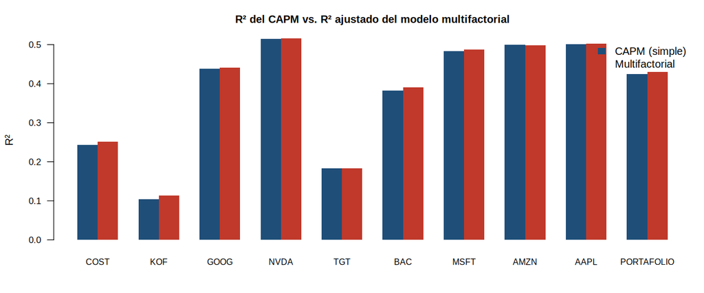

Figura 5. Poder explicativo: regresión simple vs. múltiple

### 4.1 Horas seleccionadas: variables dicótomas intradía

Tabla 9. |Rendimiento| de cada hora del portafolio (%) con variables dicótomas de hora (base: hora del mediodía)

| Hora | Coeficiente | p (HC1) |
| --- | --- | --- |
| Constante (12:30-13:30) | 0.1845 | 0.0000 |
| 09:30-10:30 | 0.2468 | 0.0000 |
| 10:30-11:30 | 0.0625 | 0.0000 |
| 11:30-12:30 | 0.0179 | 0.0781 |
| 13:30-14:30 | -0.0028 | 0.7747 |
| 14:30-15:30 | -0.0147 | 0.1206 |
| 15:30-16:00 | -0.0122 | 0.2026 |

Tabla 10. |Rendimiento| de 5 minutos: horas seleccionadas (apertura y cierre)

| Variable | Coeficiente | p (HC1) |
| --- | --- | --- |
| Constante (resto del día) | 0.0442 | 0.0000 |
| Apertura 9:30-10:30 | 0.0646 | 0.0000 |
| Cierre 15:00-16:00 | 0.0033 | 0.0649 |

En la primera hora de operación el movimiento absoluto promedio cada 5 minutos es 0.0646 puntos porcentuales mayor que en el resto del día (p = 0.0000), es decir, 2.5 veces el nivel del mediodía. En la última hora la diferencia es 0.0033 (p = 0.0649), no significativa en promedio: el efecto dominante es la apertura, cuando se incorpora la información acumulada durante la noche; el repunte del cierre se limita a los últimos 15-20 minutos de la sesión.

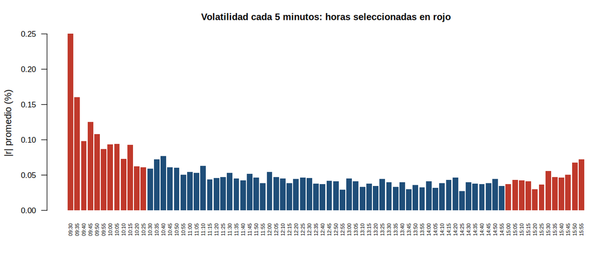

Figura 6. Patrón intradía de volatilidad del portafolio (|rendimiento| promedio cada 5 minutos)

## 5. Datos panel con reportes trimestrales

Tabla 11. Base de datos panel (empresa-trimestre)

| ticker | trimestre | fecha | crec_ingresos | margen_neto | roe | apalancamiento | rend_trim |
| --- | --- | --- | --- | --- | --- | --- | --- |
| AAPL | 2025-T4 | 2025-12-31 | 0.4030 | 0.2928 | 0.4773 | 0.7675 | 0.0632 |
| AAPL | 2026-T1 | 2026-03-31 | -0.2266 | 0.2660 | 0.2778 | 0.7130 | -0.0678 |
| AAPL | 2026-T2 | 2026-06-30 | -0.0159 | 0.2723 | 0.2771 | 0.7195 | 0.1607 |
| AAPL | 2026-T3 | 2026-09-30 | 0.0462 | 0.2683 | 0.2740 | 0.7229 | 0.1414 |
| AMZN | 2025-T3 | 2025-09-30 | 0.0743 | 0.1176 | 0.0573 | 0.4922 | 0.0008 |
| AMZN | 2025-T4 | 2025-12-31 | 0.1844 | 0.0993 | 0.0516 | 0.4975 | 0.0452 |
| AMZN | 2026-T1 | 2026-03-31 | -0.1493 | 0.1667 | 0.0685 | 0.5179 | -0.1028 |
| BAC | 2025-T3 | 2025-09-30 | 0.0582 | 0.2869 | 0.0274 | 0.9106 | 0.0919 |
| BAC | 2025-T4 | 2025-12-31 | 0.0737 | 0.2414 | 0.0248 | 0.9111 | 0.0870 |
| BAC | 2026-T1 | 2026-03-31 | -0.0291 | 0.2836 | 0.0285 | 0.9140 | -0.1150 |
| COST | 2025-T4 | 2025-11-30 | -0.2188 | 0.0297 | 0.0660 | 0.6340 | -0.0306 |
| COST | 2026-T1 | 2026-02-28 | 0.0340 | 0.0292 | 0.0634 | 0.6164 | 0.1025 |
| COST | 2026-T2 | 2026-05-31 | 0.0134 | 0.0311 | 0.0654 | 0.6123 | -0.0510 |
| COST | 2026-T3 | 2026-08-31 | 0.3573 | 0.0313 | 0.0837 | 0.5979 | -0.0115 |
| GOOG | 2025-T4 | 2025-12-31 | 0.1122 | 0.3027 | 0.0830 | 0.3024 | 0.2459 |
| GOOG | 2026-T1 | 2026-03-31 | -0.0346 | 0.5694 | 0.1307 | 0.3199 | -0.0891 |
| GOOG | 2026-T2 | 2026-06-30 | 0.0901 | 0.9365 | 0.1752 | 0.3053 | 0.2580 |
| GOOG | 2026-T3 | 2026-09-30 | 0.0650 | 0.2075 | 0.0391 | 0.3247 | -0.0356 |
| KOF | 2025-T4 | 2025-12-31 | 0.0818 | 0.0965 | 0.0513 | 0.5352 | 0.1408 |
| KOF | 2026-T1 | 2026-03-31 | -0.0879 | 0.0612 | 0.0314 | 0.5851 | 0.0295 |
| KOF | 2026-T2 | 2026-06-30 | 0.0760 | 0.0814 | 0.0436 | 0.5760 | 0.1150 |
| KOF | 2026-T3 | 2026-09-30 | 0.0446 | 0.0781 | 0.0412 | 0.5611 | 0.0276 |
| MSFT | 2025-T4 | 2025-12-31 | 0.0463 | 0.4732 | 0.0984 | 0.4125 | -0.0701 |
| MSFT | 2026-T1 | 2026-03-31 | 0.0198 | 0.3834 | 0.0767 | 0.4031 | -0.2651 |
| MSFT | 2026-T2 | 2026-06-30 | 0.0859 | 0.3974 | 0.0808 | 0.4167 | 0.0406 |
| MSFT | 2026-T3 | 2026-09-30 | 0.0252 | 0.3969 | 0.0778 | 0.3963 | 0.3203 |
| NVDA | 2025-T4 | 2025-10-31 | 0.2196 | 0.5598 | 0.2684 | 0.2622 | 0.1297 |
| NVDA | 2026-T1 | 2026-01-31 | 0.1951 | 0.6306 | 0.2731 | 0.2394 | -0.0577 |
| NVDA | 2026-T2 | 2026-04-30 | 0.1980 | 0.7146 | 0.2984 | 0.2467 | 0.0433 |
| NVDA | 2026-T3 | 2026-07-31 | 0.1790 | 0.6203 | 0.2607 | 0.2850 | 0.0127 |
| TGT | 2025-T4 | 2025-10-31 | 0.0023 | 0.0273 | 0.0444 | 0.7416 | -0.0698 |
| TGT | 2026-T1 | 2026-01-31 | 0.2051 | 0.0343 | 0.0646 | 0.7283 | 0.1414 |
| TGT | 2026-T2 | 2026-04-30 | -0.1645 | 0.0307 | 0.0476 | 0.7174 | 0.2173 |
| TGT | 2026-T3 | 2026-07-31 | 0.0431 | 0.0707 | 0.1052 | 0.7086 | 0.1237 |

Panel no balanceado con 9 empresas y 34 observaciones (trimestres fiscales homologados a trimestre calendario). KOF reporta en pesos mexicanos; como todas las regresoras son razones financieras, la moneda no afecta la comparación.

Tabla 12. Estimaciones panel (errores agrupados por empresa en MCO agrupado y efectos fijos)

| Variable | MCO agrupado β | MCO agrupado p | Efectos fijos β | Efectos fijos p | Efectos aleatorios β | Efectos aleatorios p |
| --- | --- | --- | --- | --- | --- | --- |
| (Intercept) | -0.0057 | 0.9256 |  |  | -0.0057 | 0.9568 |
| crec_ingresos | 0.1610 | 0.0788 | 0.2476 | 0.2443 | 0.1610 | 0.3722 |
| margen_neto | 0.0408 | 0.7322 | 0.1979 | 0.1201 | 0.0408 | 0.7737 |
| roe | -0.0184 | 0.8866 | -0.3148 | 0.5673 | -0.0184 | 0.9432 |
| apalancamiento | 0.0614 | 0.4673 | -1.8328 | 0.2327 | 0.0614 | 0.6755 |

Tabla 13. Bondad de ajuste

| Modelo | R2 |
| --- | --- |
| MCO agrupado | 0.036 |
| Efectos fijos | 0.139 |
| Efectos aleatorios | 0.036 |

Tabla 14. Pruebas de especificación del panel

| Prueba | Estadístico | p-valor | Contraste |
| --- | --- | --- | --- |
| F de efectos individuales | 0.7112 | 0.6792 | Efectos fijos vs. MCO agrupado |
| Breusch-Pagan LM | 1.4828 | 0.2233 | Efectos aleatorios vs. MCO agrupado |
| Hausman | 2.4933 | 0.6458 | Efectos fijos vs. efectos aleatorios |

La varianza estimada del efecto individual es cero, por lo que el estimador de efectos aleatorios coincide con el de MCO agrupado: las diferencias entre empresas no agregan información una vez que se controla por los fundamentales.

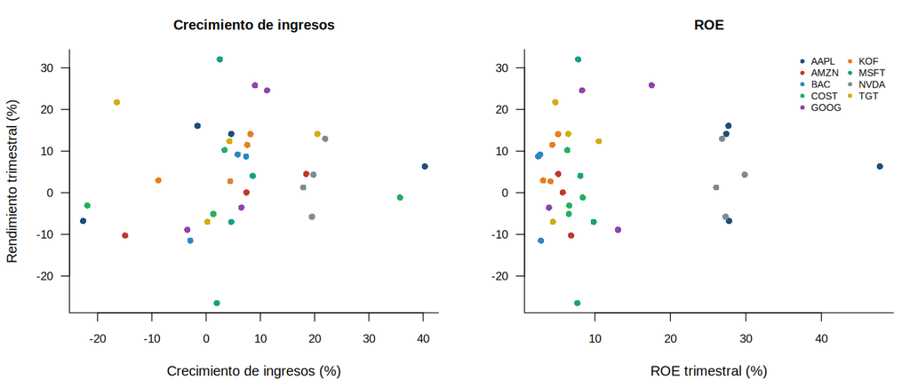

Figura 7. Fundamentales trimestrales vs. rendimiento trimestral de la acción

## 6. Series de tiempo: metodología Box-Jenkins

### 6.1 Estacionariedad

Tabla 15. Pruebas de raíz unitaria (ADF: H0 raíz unitaria; KPSS: H0 estacionariedad)

| Serie | ADF nivel p | ADF rend. p | KPSS nivel p | KPSS rend. p | d sugerida | Conclusión |
| --- | --- | --- | --- | --- | --- | --- |
| COST | 0.4451 | 0.0100 | 0.0100 | 0.1000 | 1 | I(1): raíz unitaria en niveles |
| KOF | 0.3299 | 0.0100 | 0.0100 | 0.1000 | 1 | I(1): raíz unitaria en niveles |
| GOOG | 0.2827 | 0.0100 | 0.0100 | 0.1000 | 1 | I(1): raíz unitaria en niveles |
| NVDA | 0.5170 | 0.0100 | 0.0100 | 0.1000 | 1 | I(1): raíz unitaria en niveles |
| TGT | 0.6790 | 0.0100 | 0.0100 | 0.1000 | 1 | I(1): raíz unitaria en niveles |
| BAC | 0.2609 | 0.0100 | 0.0100 | 0.1000 | 1 | I(1): raíz unitaria en niveles |
| MSFT | 0.2919 | 0.0100 | 0.0100 | 0.1000 | 1 | I(1): raíz unitaria en niveles |
| AMZN | 0.1100 | 0.0100 | 0.0100 | 0.1000 | 1 | I(1): raíz unitaria en niveles |
| AAPL | 0.2362 | 0.0100 | 0.0100 | 0.1000 | 1 | I(1): raíz unitaria en niveles |
| PORTAFOLIO | 0.2521 | 0.0100 | 0.0100 | 0.1000 | 1 | I(1): raíz unitaria en niveles |

Los log-precios no son estacionarios (ADF no rechaza la raíz unitaria y KPSS sí rechaza la estacionariedad), mientras que sus primeras diferencias, los rendimientos, sí lo son. Las series son integradas de orden uno, I(1): se modelan los rendimientos con ARMA(p,q) o, equivalentemente, el log-precio con ARIMA(p,1,q).

### 6.2 Descomposición, periodicidad y persistencia

Tabla 16. Exponente de Hurst del log-precio (H = 0.5: paseo aleatorio)

| Serie | Hurst | Interpretación |
| --- | --- | --- |
| COST | 0.381 | reversión a la media |
| KOF | 0.433 | reversión a la media |
| GOOG | 0.500 | ≈ paseo aleatorio |
| NVDA | 0.529 | ≈ paseo aleatorio |
| TGT | 0.491 | ≈ paseo aleatorio |
| BAC | 0.455 | ≈ paseo aleatorio |
| MSFT | 0.479 | ≈ paseo aleatorio |
| AMZN | 0.439 | reversión a la media |
| AAPL | 0.436 | reversión a la media |
| PORTAFOLIO | 0.366 | reversión a la media |

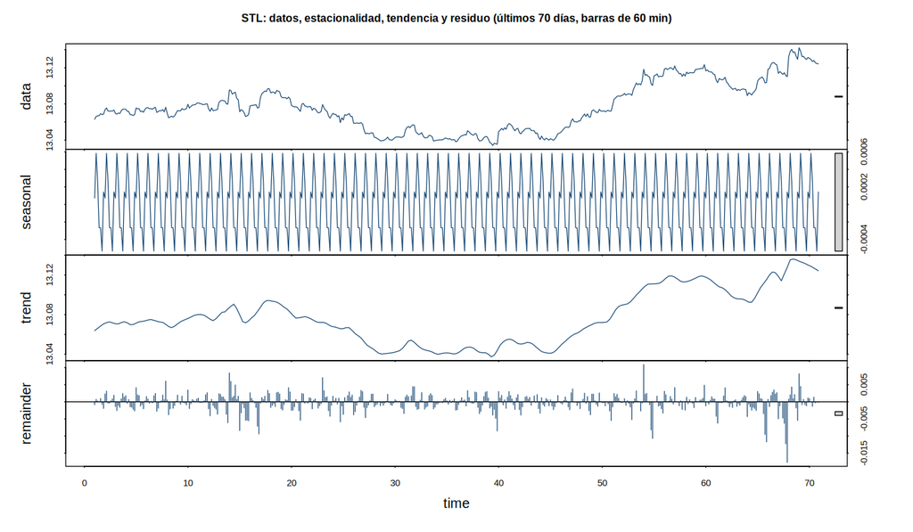

Figura 8. Descomposición STL del log-valor horario del portafolio (periodo = 7 barras = 1 sesión)

Tabla 17. Fuerza de los componentes STL (0 = nula, 1 = total)

| Componente | Valor |
| --- | --- |
| Fuerza de la tendencia | 0.990 |
| Fuerza de la estacionalidad intradía | 0.027 |

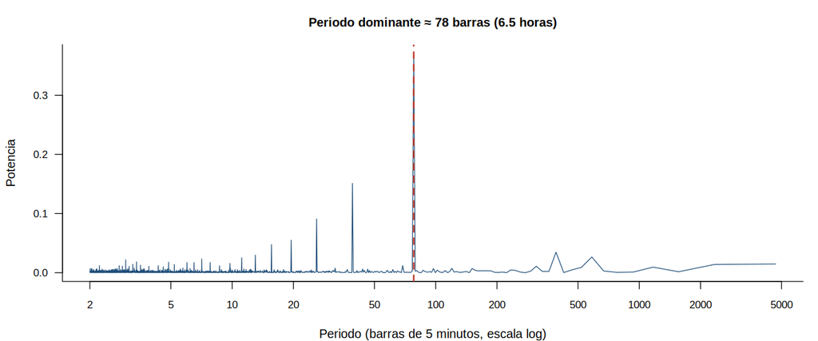

Figura 9. Periodograma (FFT) de la volatilidad de 5 minutos del portafolio

La descomposición STL muestra una estacionalidad intradía débil frente a la tendencia (fuerza de estacionalidad = 0.03) en el nivel de precios. La transformada de Fourier aplicada a la volatilidad sí detecta un ciclo dominante de 78 barras de 5 minutos (≈ 6.5 horas, una sesión bursátil): la volatilidad sí tiene estacionalidad diaria, aunque el precio no. El exponente de Hurst promedio de las acciones es 0.46, cercano a 0.5 (paseo aleatorio); el del portafolio, 0.37, sugiere cierta reversión a la media, aunque este estimador es sensible a la muestra y debe tomarse con cautela.

### 6.3 Identificación: ACF y PACF

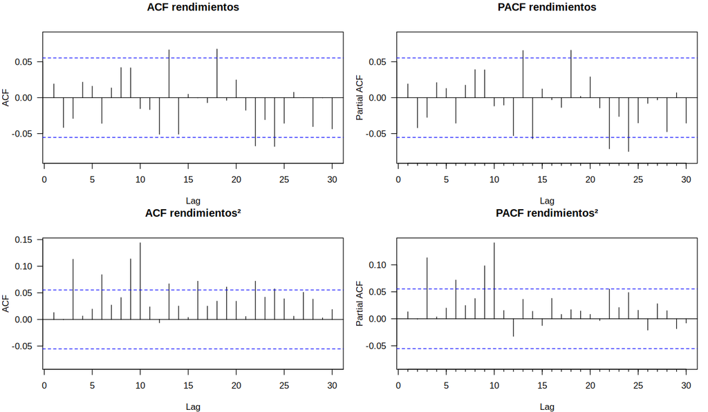

Figura 10. ACF y PACF de los rendimientos diarios del portafolio y de sus cuadrados

Tabla 18. Prueba Ljung-Box sobre los rendimientos diarios del portafolio

| Rezagos | p Ljung-Box rendimientos | p Ljung-Box rendimientos² |
| --- | --- | --- |
| 5 | 0.4682 | 0.0048 |
| 10 | 0.3477 | 0.0000 |
| 20 | 0.0635 | 0.0000 |

La ACF y la PACF de los rendimientos tienen pocos rezagos fuera de las bandas de confianza, lo que sugiere modelos de orden bajo (AR(1), MA(1) o ARMA(1,1)). En cambio, los rendimientos al cuadrado muestran autocorrelación fuerte y persistente: hay efectos ARCH, que justifican el modelo GARCH de la sección 7.

### 6.4 Estimación de modelos AR, MA, ARMA y ARIMA

Tabla 19. Modelos estimados sobre los rendimientos diarios del portafolio (*** p<0.01, ** p<0.05, * p<0.1)

| Modelo | AIC | BIC | Log-verosimilitud | p Ljung-Box (10) | Coeficientes |
| --- | --- | --- | --- | --- | --- |
| AR(1) | -7,599.31 | -7,583.91 | 3,802.66 | 0.31 | ar1 = 0.0191; intercept = 0.0006* |
| AR(2) | -7,599.51 | -7,578.98 | 3,803.76 | 0.45 | ar1 = 0.0199; ar2 = -0.0419; intercept = 0.0006* |
| MA(1) | -7,599.35 | -7,583.95 | 3,802.68 | 0.31 | ma1 = 0.0208; intercept = 0.0006* |
| MA(2) | -7,599.33 | -7,578.79 | 3,803.66 | 0.43 | ma1 = 0.0177; ma2 = -0.0391; intercept = 0.0006* |
| ARMA(1,1) | -7,597.81 | -7,577.27 | 3,802.91 | 0.27 | ar1 = -0.2823; ma1 = 0.3090; intercept = 0.0006* |
| ARMA(2,1) | -7,597.95 | -7,572.28 | 3,803.98 | 0.40 | ar1 = 0.2791; ar2 = -0.0492*; ma1 = -0.2597; intercept = 0.0006** |
| ARMA(1,2) | -7,597.78 | -7,572.11 | 3,803.89 | 0.38 | ar1 = 0.2639; ma1 = -0.2453; ma2 = -0.0465*; intercept = 0.0006** |
| ARMA(2,2) | -7,600.33 | -7,569.53 | 3,806.17 | 0.68 | ar1 = 0.1895; ar2 = -0.8349***; ma1 = -0.1765; ma2 = 0.7935***; intercept = 0.0006* |

Por AIC el mejor modelo para los rendimientos es ARMA(2,2) y por BIC MA(1). Como los rendimientos son la primera diferencia del log-precio, ARMA(2,2) sobre los rendimientos equivale a ARIMA(2,1,2) sobre el log-valor del portafolio. La búsqueda automática (auto.arima) sobre el log-valor selecciona ARIMA(0,1,0) with drift. Las diferencias de AIC entre modelos son menores a 3 puntos, señal de que la parte predecible de los rendimientos es reducida. El BIC, que penaliza más los parámetros, prefiere MA(1); en ARMA(2,2) los coeficientes AR y MA de orden alto tienden a compensarse (raíces casi comunes), un síntoma de sobreparametrización. Por eso se reporta ARMA(2,2) por su ajuste y se contrasta su pronóstico contra el paseo aleatorio.

### 6.5 Diagnóstico de residuos

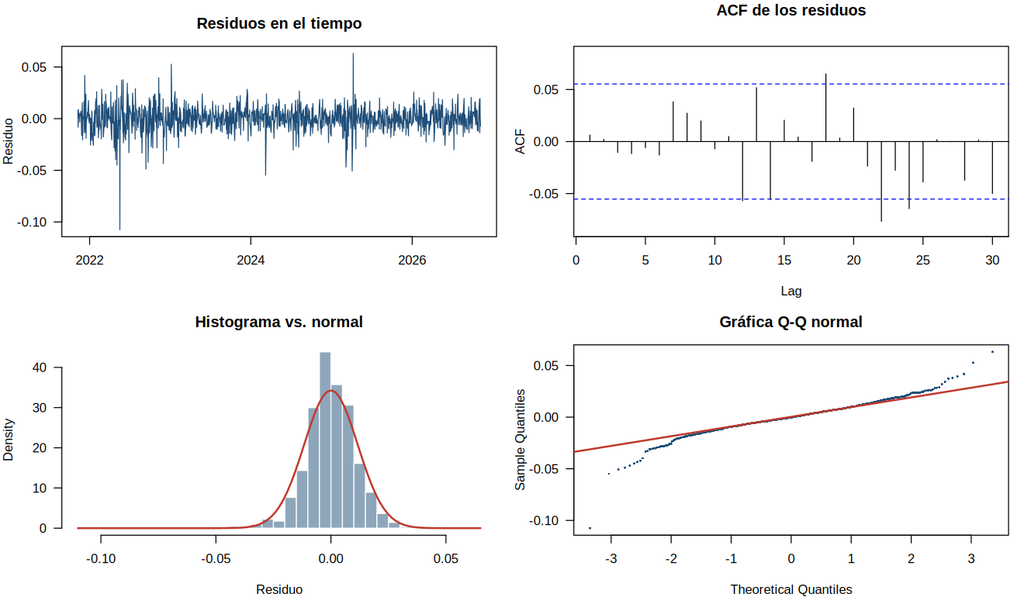

Figura 11. Diagnóstico de residuos del modelo ARMA(2,2)

Tabla 20. Ljung-Box sobre los residuos del ARMA(2,2)

| Rezagos | p Ljung-Box residuos | p Ljung-Box residuos² |
| --- | --- | --- |
| 5 | 0.5240 | 0.0107 |
| 10 | 0.6836 | 0.0000 |
| 20 | 0.1097 | 0.0000 |

Los p-valores de Ljung-Box sobre los residuos (0.524, 0.684, 0.110) indican que se comportan como ruido blanco. Los residuos al cuadrado sí están autocorrelacionados y las colas son más pesadas que la normal: la media queda bien modelada por el ARMA, pero la varianza no es constante, lo que se resuelve con GARCH.

### 6.6 Pronóstico diario (forecast)

Tabla 21. ARIMA diario: validación con los últimos 20 días y pronóstico a 10 días hábiles (IC 95%)

| Serie | Modelo | AIC | RMSE ARIMA | RMSE paseo aleatorio | MAPE % | Último | Pronóstico | LI 95% | LS 95% | Cambio esperado % |
| --- | --- | --- | --- | --- | --- | --- | --- | --- | --- | --- |
| PORTAFOLIO | ARIMA(2,1,2) with drift | -7,600.32 | 16,384.81 | 19,243.72 | 3.12 | 501,129.99 | 504,061.02 | 469,408.61 | 541,271.51 | 0.58 |
| COST | ARIMA(1,1,1) with drift | -7,044.66 | 64.71 | 64.80 | 5.67 | 1,053.56 | 1,060.28 | 967.59 | 1,161.85 | 0.64 |
| KOF | ARIMA(0,1,0) with drift | -6,884.66 | 6.02 | 6.77 | 4.90 | 114.43 | 115.28 | 104.70 | 126.93 | 0.74 |
| GOOG | ARIMA(0,1,0) | -6,196.04 | 42.46 | 42.46 | 11.45 | 283.93 | 283.93 | 250.14 | 322.28 | 0.00 |
| NVDA | ARIMA(1,1,0) with drift | -5,038.91 | 25.64 | 21.19 | 10.70 | 186.64 | 189.13 | 155.98 | 229.32 | 1.33 |
| TGT | ARIMA(0,1,0) | -5,861.05 | 3.71 | 3.71 | 1.81 | 158.41 | 158.41 | 137.06 | 183.09 | 0.00 |
| BAC | ARIMA(0,1,1) | -6,693.81 | 3.63 | 3.58 | 6.78 | 49.42 | 49.41 | 44.19 | 55.24 | -0.03 |
| MSFT | ARIMA(0,1,0) | -6,541.76 | 10.37 | 10.37 | 1.46 | 530.61 | 530.61 | 475.16 | 592.53 | 0.00 |
| AMZN | ARIMA(0,1,0) | -5,893.62 | 10.65 | 10.65 | 3.42 | 259.30 | 259.30 | 224.77 | 299.14 | 0.00 |
| AAPL | ARIMA(0,1,0) | -6,559.72 | 7.82 | 7.82 | 2.09 | 342.37 | 342.37 | 306.83 | 382.02 | 0.00 |

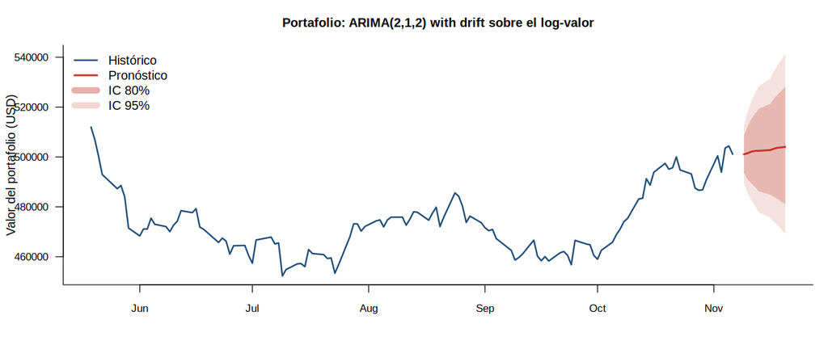

Figura 12. Pronóstico del valor del portafolio a 10 días hábiles con intervalos de 80% y 95%

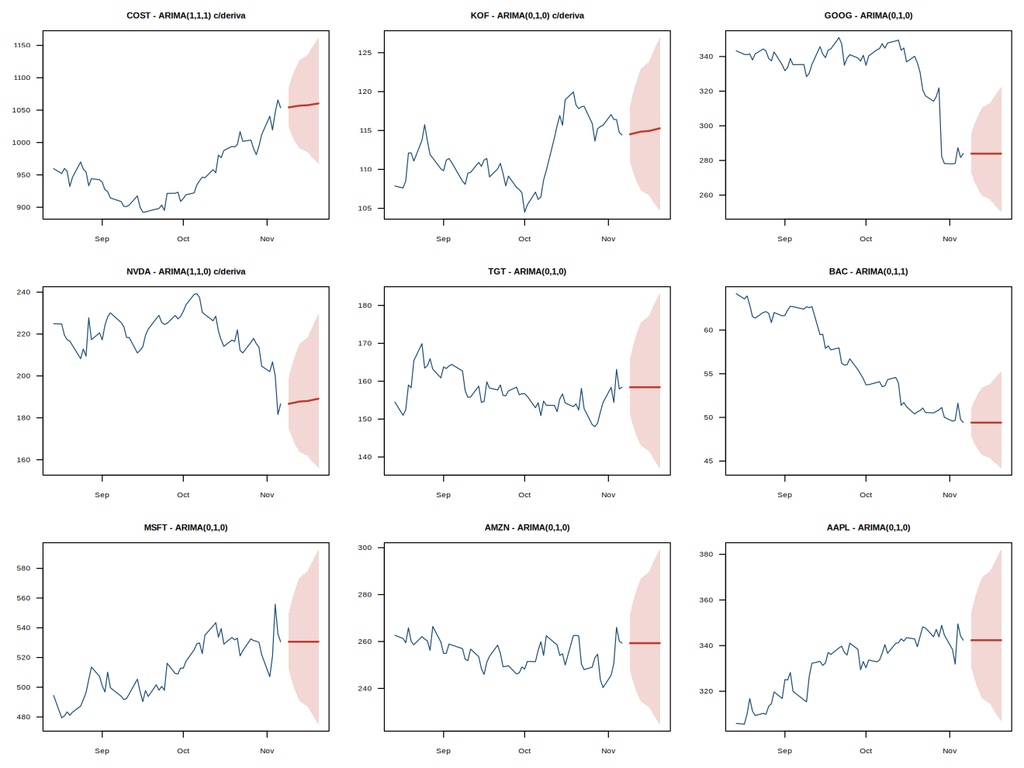

Figura 13. Pronóstico ARIMA a 10 días por acción (IC 95%)

El modelo ARIMA tuvo menor error de pronóstico que el paseo aleatorio en 3 de 10 series durante los últimos 20 días. El pronóstico del portafolio a 10 días es $504,061.02, con intervalo de 95% entre $469,408.61 y $541,271.51. Los intervalos se amplían con el horizonte y los pronósticos puntuales son casi planos: consistente con la hipótesis de mercados eficientes en su forma débil, donde los precios pasados aportan poca información sobre los futuros.

### 6.7 Pronóstico intradía: horas y minutos

Tabla 22. Pronóstico del portafolio por hora: validación con la última sesión (7 barras de 60 min)

| Modelo | Especificación | RMSE (USD) | MAPE % |
| --- | --- | --- | --- |
| SARIMA | ARIMA(0,1,0)(0,0,2)[7] | 1,483.646 | 0.227 |
| ARIMA | ARIMA(0,1,0) | 2,454.247 | 0.438 |
| Paseo aleatorio | ARIMA(0,1,0) | 2,454.247 | 0.438 |
| ETS (suavizamiento exponencial) | ETS(M,Ad,A) | 2,634.401 | 0.500 |

Tabla 23. Pronóstico intradía del valor del portafolio

| Serie | Modelo | Horizonte | Último | Pronóstico | LI 95% | LS 95% |
| --- | --- | --- | --- | --- | --- | --- |
| Portafolio 60 min | ARIMA(0,1,0)(0,0,2)[7] | 7 horas | 501,001.36 | 500,802.86 | 491,293.06 | 510,496.74 |
| Portafolio 5 min | ARIMA(2,1,2) | 60 minutos | 501,001.36 | 500,948.69 | 496,758.37 | 505,174.35 |
| Portafolio 1 min | ARIMA(3,1,0) | 30 minutos | 501,001.36 | 501,001.30 | 497,200.85 | 504,830.80 |

Tabla 24. Pronóstico ARIMA por acción a 7 horas

| Acción | Último | Pronóstico | LI 95% | LS 95% |
| --- | --- | --- | --- | --- |
| COST | 1,053.49 | 1,053.49 | 1,026.93 | 1,080.73 |
| KOF | 114.34 | 114.31 | 110.92 | 117.81 |
| GOOG | 283.73 | 283.73 | 270.53 | 297.58 |
| NVDA | 186.68 | 186.68 | 178.08 | 195.69 |
| TGT | 158.41 | 158.41 | 152.49 | 164.56 |
| BAC | 49.41 | 48.39 | 45.70 | 51.23 |
| MSFT | 530.55 | 531.49 | 508.70 | 555.31 |
| AMZN | 259.35 | 259.35 | 246.57 | 272.79 |
| AAPL | 342.36 | 342.36 | 329.28 | 355.97 |

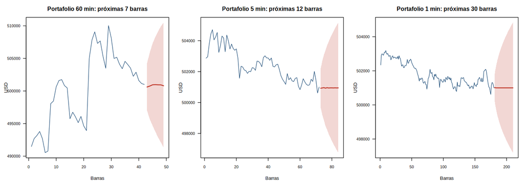

Figura 14. Pronóstico del valor del portafolio por hora y por minuto (IC 95%)

En datos por hora el mejor modelo fuera de muestra fue SARIMA. A frecuencias de minutos los modelos seleccionados son de orden muy bajo y los intervalos de confianza son estrechos en valor absoluto pero crecen rápido con el horizonte: la información de corto plazo se incorpora casi de inmediato a los precios.

## 7. Modelos GARCH

Tabla 25. GARCH(1,1) con distribución t: parámetros, volatilidad y VaR

| Activo | ω | α | β | α+β | ν (t) | Vol. actual anual % | Vol. pronosticada anual % | VaR 95% 1 periodo % |
| --- | --- | --- | --- | --- | --- | --- | --- | --- |
| COST | 0.0497 | 0.0265 | 0.9485 | 0.9750 | 4.6102 | 22.7295 | 22.6195 | 2.0990 |
| KOF | 0.9615 | 0.0905 | 0.5124 | 0.6029 | 9.1748 | 23.5805 | 24.2919 | 2.2791 |
| GOOG | 0.0631 | 0.0225 | 0.9639 | 0.9864 | 4.3091 | 41.0633 | 40.1955 | 3.8074 |
| NVDA | 0.1615 | 0.0486 | 0.9359 | 0.9845 | 6.3603 | 52.4620 | 51.8735 | 5.0178 |
| TGT | 0.0327 | 0.0034 | 0.9886 | 0.9920 | 4.1328 | 32.1049 | 32.0535 | 3.0481 |
| BAC | 0.6308 | 0.1133 | 0.6727 | 0.7861 | 4.5367 | 34.8089 | 29.1202 | 3.0006 |
| MSFT | 0.0706 | 0.0593 | 0.9220 | 0.9813 | 4.6589 | 37.5670 | 36.1256 | 3.4922 |
| AMZN | 0.0365 | 0.0181 | 0.9746 | 0.9927 | 4.8214 | 36.7591 | 36.3960 | 3.5066 |
| AAPL | 0.0785 | 0.0662 | 0.9122 | 0.9784 | 4.5329 | 30.1923 | 29.3759 | 2.7507 |
| PORTAFOLIO | 0.0306 | 0.0336 | 0.9412 | 0.9749 | 5.7536 | 16.3901 | 16.4186 | 1.5415 |
| PORTAFOLIO (60 min) | 0.0042 | 0.0401 | 0.9240 | 0.9640 | 3.6139 | 15.3341 | 14.9314 | 0.5171 |

En el portafolio, α + β = 0.975: los choques de volatilidad son muy persistentes y se disipan lentamente. La volatilidad anualizada actual es 16.4% y la pronosticada para los próximos 10 días es 16.4%. El VaR al 95% a un día es 1.54% del valor, es decir, $7,724.87: en 1 de cada 20 días se esperaría una pérdida mayor a esa cifra.

Tabla 26. Comparación de modelos de volatilidad del portafolio (menor AIC = mejor)

| Modelo | Log-verosimilitud | AIC | BIC | γ (asimetría) | p γ (robusto) |
| --- | --- | --- | --- | --- | --- |
| GARCH(1,1) | -1,854.4309 | 2.9656 | 2.9861 |  |  |
| GJR-GARCH(1,1) | -1,853.5455 | 2.9658 | 2.9903 | 0.0244 | 0.1806 |
| EGARCH(1,1) | -1,852.7644 | 2.9645 | 2.9891 | 0.0788 | 0.0004 |

El mejor modelo de volatilidad por AIC es EGARCH(1,1), aunque las diferencias de AIC entre los tres son mínimas. En GJR-GARCH el término γ mide el efecto apalancamiento (las caídas aumentan la volatilidad más que las subidas de igual magnitud): γ = 0.0244 con p = 0.181, no significativo: en este portafolio, dominado por acciones defensivas de consumo, no hay evidencia clara de asimetría.

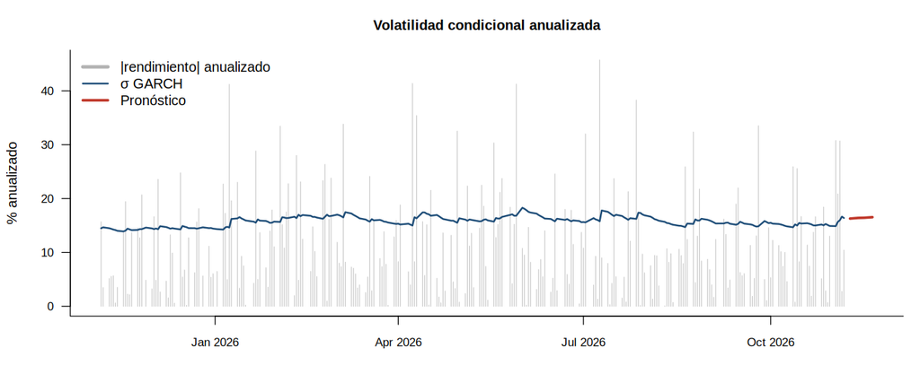

Figura 15. Volatilidad condicional GARCH(1,1) del portafolio y pronóstico

## 8. Estrategias del portafolio

Tabla 27. Pesos por estrategia (%), estimados con datos de entrenamiento

| Acción | Actual (HTMW) | Igual peso | Mínima varianza | Máximo Sharpe | Momentum top 4 |
| --- | --- | --- | --- | --- | --- |
| COST | 63.1 | 11.1 | 30.0 | 30.0 | 0 |
| KOF | 22.8 | 11.1 | 30.0 | 30.0 | 25 |
| GOOG | 5.7 | 11.1 | 3.0 | 14.0 | 25 |
| NVDA | 3.7 | 11.1 | 0.0 | 26.0 | 25 |
| TGT | 1.6 | 11.1 | 1.9 | 0.0 | 25 |
| BAC | 1.5 | 11.1 | 18.9 | 0.0 | 0 |
| MSFT | 1.1 | 11.1 | 14.5 | 0.0 | 0 |
| AMZN | 0.5 | 11.1 | 0.0 | 0.0 | 0 |
| AAPL | 0.1 | 11.1 | 1.7 | 0.0 | 0 |

Tabla 28. Desempeño fuera de muestra (últimos 126 días hábiles)

| Estrategia | Rend. acumulado % | Rend. anual % | Vol. anual % | Sharpe | Máx. caída % | Beta |
| --- | --- | --- | --- | --- | --- | --- |
| Actual (HTMW) | 4.37 | 8.94 | 15.21 | 0.32 | -11.44 | -0.03 |
| Igual peso | 4.87 | 9.97 | 14.67 | 0.41 | -5.71 | 0.75 |
| Mínima varianza | 8.76 | 18.28 | 13.18 | 1.08 | -6.33 | 0.28 |
| Máximo Sharpe | -2.17 | -4.29 | 13.83 | -0.60 | -9.05 | 0.62 |
| Momentum top 4 | -1.04 | -2.08 | 17.77 | -0.34 | -9.56 | 0.88 |
| S&P 500 | -0.30 | -0.60 | 13.63 | -0.34 | -5.95 | 1.00 |

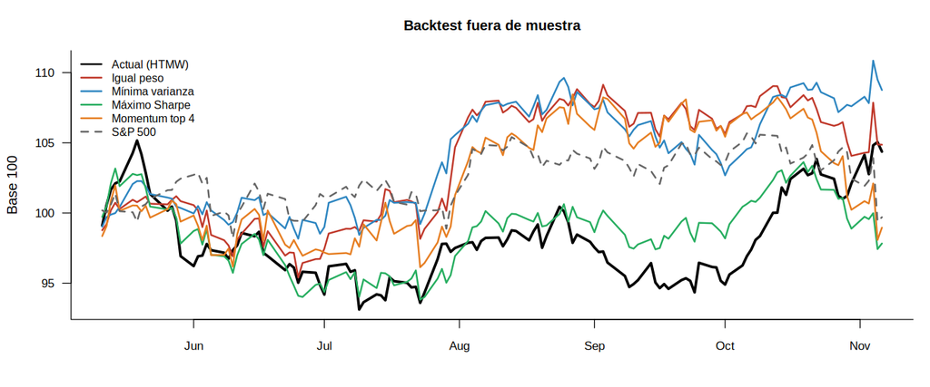

Figura 16. Evolución de las estrategias fuera de muestra vs. S&P 500 (base 100)

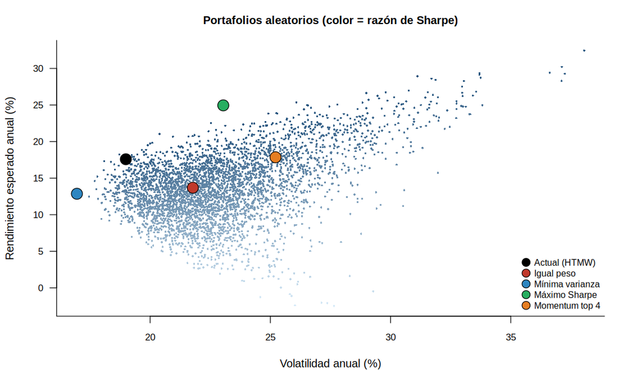

Figura 17. Conjunto de oportunidades de inversión y estrategias (datos de entrenamiento)

Tabla 29. Rebalanceo hacia la estrategia «Mínima varianza» (pesos re-estimados con toda la muestra)

| Acción | Acciones actuales | Peso objetivo % | Acciones objetivo | Diferencia | Orden en HTMW |
| --- | --- | --- | --- | --- | --- |
| COST | 300 | 30.0 | 142 | -158 | Vender 158 |
| KOF | 1,000 | 30.0 | 1,313 | 313 | Comprar 313 |
| GOOG | 100 | 3.8 | 67 | -33 | Vender 33 |
| NVDA | 100 | 0.0 | 0 | -100 | Vender 100 |
| TGT | 50 | 1.7 | 53 | 3 | Comprar 3 |
| BAC | 150 | 19.6 | 1,990 | 1,840 | Comprar 1840 |
| MSFT | 10 | 12.2 | 115 | 105 | Comprar 105 |
| AMZN | 10 | 0.0 | 0 | -10 | Vender 10 |
| AAPL | 1 | 2.6 | 38 | 37 | Comprar 37 |

Fuera de muestra, la mejor razón de Sharpe la obtuvo «Mínima varianza» (1.08), frente a 0.32 del portafolio actual y -0.34 del S&P 500. El portafolio actual tiene 63% en una sola emisora, por encima del límite de 30% que usan las estrategias optimizadas; diversificar reduce el riesgo específico sin sacrificar necesariamente rendimiento. La Tabla 29 traduce la estrategia a órdenes de compra y venta en HowTheMarketWorks (ejercicio académico).

Fuera de muestra, la beta del portafolio actual fue de apenas -0.03, muy por debajo de su beta histórica (0.70): en los últimos seis meses COST, que pesa 63%, se movió en sentido contrario al mercado (ver la beta móvil de la sección 3). Ese cambio de régimen explica que el portafolio no acompañara al S&P 500 en los periodos de alza ni de baja.

## 9. Conclusiones

**Regresión lineal simple.** La beta diaria del portafolio es 0.70 (R² = 0.42). NVDA es la acción más sensible al mercado (β = 2.16) y KOF la más defensiva (β = 0.46). Con datos de minutos el R² cae (efecto Epps), y la beta móvil muestra un cambio de régimen: en los últimos seis meses COST tuvo beta -0.39 y el portafolio 0.00.

**Regresión lineal múltiple.** Agregar VIX, tasa a 10 años, USD/MXN y petróleo lleva el R² ajustado promedio de 0.372 a 0.376, sin multicolinealidad (VIF máximo 2.50): el mercado explica casi todo. En las horas seleccionadas, la volatilidad de la primera hora es 2.5 veces la del resto del día; el cierre no es significativamente distinto.

**Datos panel.** Con los reportes trimestrales, las pruebas de especificación favorecen el modelo de MCO agrupado (Hausman p = 0.646). La muestra es corta, por lo que la relación entre fundamentales y rendimiento es exploratoria.

**Series de tiempo (Box-Jenkins).** Los log-precios son I(1) y los rendimientos estacionarios. La ACF/PACF sugiere órdenes bajos; el mejor modelo por AIC es ARMA(2,2) (≡ ARIMA(2,1,2) en el log-valor) con residuos sin autocorrelación, aunque el BIC y auto.arima prefieren modelos más simples. El ARIMA supera al paseo aleatorio en 3 de 10 series; el pronóstico del portafolio a 10 días es $504,061.02 (IC 95%: $469,408.61 a $541,271.51).

**Intradía.** Por hora, el mejor modelo fuera de muestra fue SARIMA; la volatilidad tiene un ciclo dominante de una sesión (FFT ≈ 78 barras de 5 min).

**GARCH.** Persistencia α+β = 0.975; el mejor modelo de volatilidad es EGARCH(1,1). VaR 95% diario ≈ $7,724.87 sobre un valor de $501,129.99.

**Desempeño en HowTheMarketWorks.** La cuenta rinde 1.53% contra -4.90% del SPY (6.43 puntos porcentuales por encima del mercado).

**Estrategias.** Fuera de muestra, «Mínima varianza» tuvo la mejor razón de Sharpe (1.08 vs. 0.32 del portafolio actual). La alta concentración en COST es el principal riesgo del portafolio.

## 10. Evidencia: operaciones en HowTheMarketWorks

Capturas de pantalla del concurso «Econometría Financiera EGADE Oct 26» en HowTheMarketWorks: saldo de la cuenta, posiciones abiertas e historial de órdenes (3 imágenes).

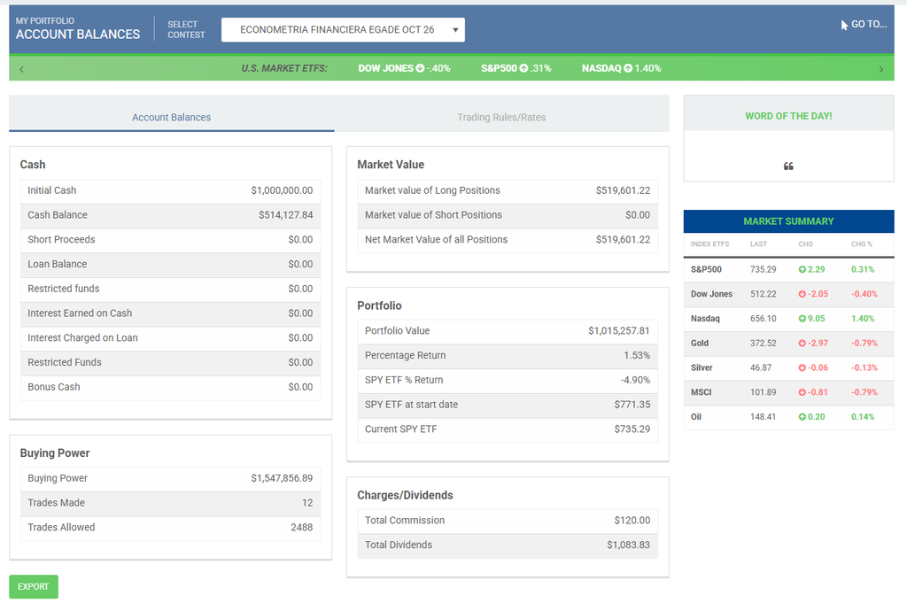

Captura HowTheMarketWorks: HOWMARKETWORKS 1.png

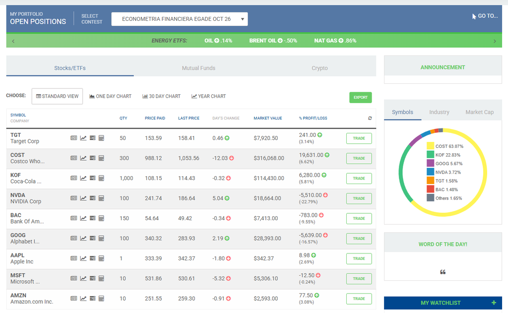

Captura HowTheMarketWorks: HOWMARKETWORKS 2.png

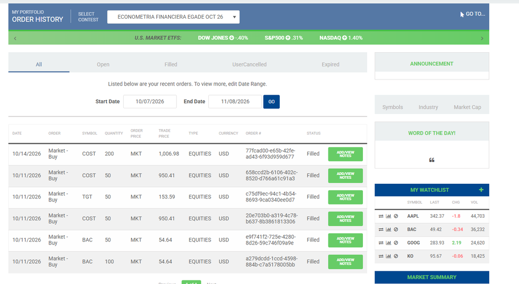

Captura HowTheMarketWorks: HOWMARKETWORKS 3.png

## 11. Entregables

Notebook en Google Colab: https://colab.research.google.com/drive/1ErHpG2S5Sf7DTRsmbjekwdNcrcA0cfZP?usp=sharing

Repositorio en GitHub: https://github.com/CSalvide/econometria-financiera-portafolio

Prompt de GitHub Copilot: https://github.com/CSalvide/econometria-financiera-portafolio/blob/main/PROMPT_COPILOT.md

Referencias: Gujarati, D. N. y Porter, D. C., Econometría, McGraw-Hill. Box, G. E. P., Jenkins, G. M., Reinsel, G. C. y Ljung, G. M., Time Series Analysis: Forecasting and Control, Wiley. Bollerslev, T. (1986), Generalized autoregressive conditional heteroskedasticity, Journal of Econometrics, 31(3). Bianchi, F. M., Time series analysis with Python (https://filippomb.github.io/python-time-series-handbook/). Hyndman, R. J. y Athanasopoulos, G., Forecasting: Principles and Practice (https://otexts.com/fpp3/).